# Eye sight - Near vision

# 1 Description of DataSchema variable

The description of harmonised variable is the following:

- Short name: `eye_near`
- Variable label: `Eyesight - Near vision`
- Variable description: `Difficulties for near vision.`
- Domain: `Health status and functional limitations`
- Value type: `categorical`
- Category coding:

| **Code** | **Category Label** |
| --- | --- |
| 0 | Yes |
| 1 | No |

- Category missings:

| **Code** | **Category Label** |
| --- | --- |
| 991 | CAPI/interviewer error |
| 992 | Impute |
| 993 | Disable to measure |
| 994 | Not attempt/not done |
| 995 | Does not answer |
| 996 | Not applicable |
| 997 | Refuse |
| 998 | Do not know |
| 999 | Missing |

# 2 Data process

## 2.1 England

### 2.1.1 Wave 1

#### 2.1.1.1 Study-specific variable description

| **Name** | `hepap` | `heeye` |
| --- | --- | --- |
| **Label** | `How good is your eyesight for seeing things up close, like reading ordinary newspaper print (using glasses or corrective lens as usual)?` | `Is your eyesight (using glasses or corrective lens as usual) ...?` |
| **Table name** | `wave_1_core_data_v3` | `wave_1_core_data_v3` |
| **Categories** | `1 = ...excellent; 2 = very good; 3 = good; 4 = fair; 5 = or, poor?` | `1 = ...excellent; 2 = very good; 3 = good; 4 = fair; 5 = or, poor?; 6 = SPONTANEOUS: Registered or legally blind` |
| **Missings** | `-9 = Refusal; -8 = Don't Know; -1 = Not applicable` | `-9 = Refusal; -8 = Don't Know` |
| **Description** |  |  |

hepap

| Sample size | Missing values |
| --- | --- |
| 12099 | 244 |

Category

|  | 1 | 2 | 3 | 4 | 5 |
| --- | --- | --- | --- | --- | --- |
| Frequency | 2301.00 | 4064.00 | 4097.00 | 999.00 | 394.00 |
| Percentage | 19.02 | 33.59 | 33.86 | 8.26 | 3.26 |

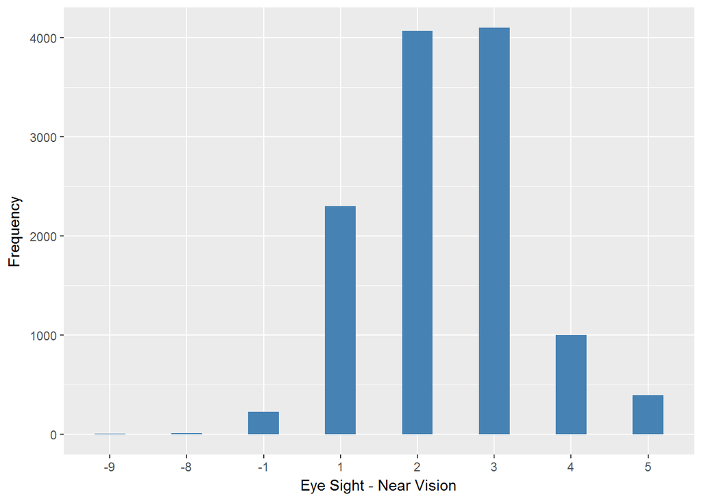

heeye

| Sample size | Missing values |
| --- | --- |
| 12099 | 9 |

Category

|  | 1 | 2 | 3 | 4 | 5 | 6 |
| --- | --- | --- | --- | --- | --- | --- |
| Frequency | 1876.00 | 3655.00 | 4620.00 | 1448.00 | 435.0 | 56.00 |
| Percentage | 15.51 | 30.21 | 38.18 | 11.97 | 3.6 | 0.46 |

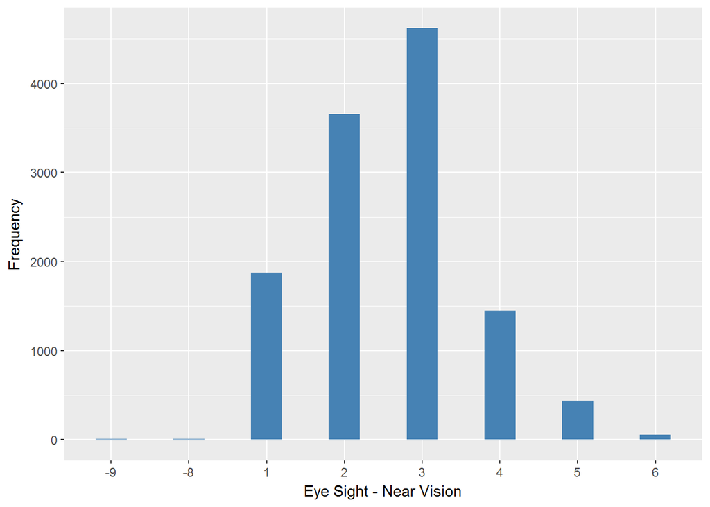

#### 2.1.1.2 Harmonisation algorithm

To compute the harmonize variable from the study-specific variable it has to be recoded as follows:

- `hepap == 1, 2, 3 into 1`
- `hepap == 4, 5 into 0`
- `hepap == -9 Refusal into 997`
- `hepap == -8 Don't know into 998`
- `hepap == -1 Item not applicable into 996`
- `heeye == 6 into 0`

**R script:**

```r
ELSA_ds_w1 <- tibble(id = ELSA_w1_eye_near$id)
ELSA_ds_w1$eye_near <- car::recode(ELSA_w1_eye_near$hepap, "1 = '1';2 = '1';3 = '1';4 = '0'; 5 = '0';-9 = '997';-8 = '998';-1 = '996' ")

ELSA_ds_w1$eye_near[!is.na(ELSA_w1_eye_near$heeye) & ELSA_w1_eye_near$heeye ==
    6] <- 0

ELSA_ds_w1$eye_near <- labelled(ELSA_ds_w1$eye_near, labels = c(Yes = 0, No = 1,
    Missing = 999, Do_not_know = 998, Refuse = 997, Not_applicable = 996, Does_not_answer = 995,
    Not_attempt_not_done = 994, Disable_to_measure = 993, Impute = 992, CAPI_interviewer_error = 991))
```

#### 2.1.1.3 Statistical description of the new harmonised variable

eye_near

| Sample size | Missing values |
| --- | --- |
| 12099 | 188 |

Category

|  | 0 | 1 |
| --- | --- | --- |
| Frequency | 1449.00 | 10462.00 |
| Percentage | 11.98 | 86.47 |

Type of missing

|  | 991 | 992 | 993 | 994 | 995 | 996 | 997 | 998 | 999 | NA |
| --- | --- | --- | --- | --- | --- | --- | --- | --- | --- | --- |
| Frequency | 0 | 0 | 0 | 0 | 0 | 171.00 | 5.00 | 12.0 | 0 | 0 |
| Percentage | 0 | 0 | 0 | 0 | 0 | 1.41 | 0.04 | 0.1 | 0 | 0 |

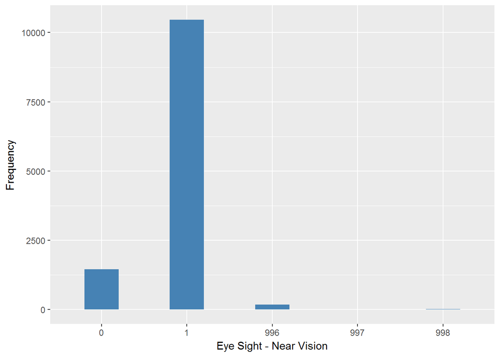

#### 2.1.1.4 Validation

|  | 4,5,heeye==6->0 | 1,2,3->1 | -1->996 | -9->997 | -8->998 |
| --- | --- | --- | --- | --- | --- |
| BeforeH | 1449 | 10462 | 171 | 5 | 12 |
| AfterH | 1449 | 10462 | 171 | 5 | 12 |

### 2.1.2 Wave 2

#### 2.1.2.1 Study-specific variable description

| **Name** | `Hepap` | `Heeye` |
| --- | --- | --- |
| **Label** | `How good is your eyesight for seeing things up close, like reading ordinary newspaper print (using glasses or corrective lens as usual)?` | `Self-reported eyesight (while using lenses, if appropriate)?` |
| **Table name** | `wave_2_core_data_v4` | `wave_2_core_data_v4` |
| **Categories** | `1 = ...excellent; 2 = very good; 3 = good; 4 = fair; 5 = or, poor?` | `1 = ...excellent; 2 = very good; 3 = good; 4 = fair; 5 = or, poor?; 6 = SPONTANEOUS: Registered or legally blind` |
| **Missings** | `-9 = Refusal; -8 = Don't Know; -1 = Not applicable` | `-9 = Refusal; -8 = Don't Know` |
| **Description** |  |  |

Hepap

| Sample size | Missing values |
| --- | --- |
| 9432 | 167 |

Category

|  | 1 | 2 | 3 | 4 | 5 |
| --- | --- | --- | --- | --- | --- |
| Frequency | 1601.00 | 3332.00 | 3285.00 | 770.00 | 277.00 |
| Percentage | 16.97 | 35.33 | 34.83 | 8.16 | 2.94 |

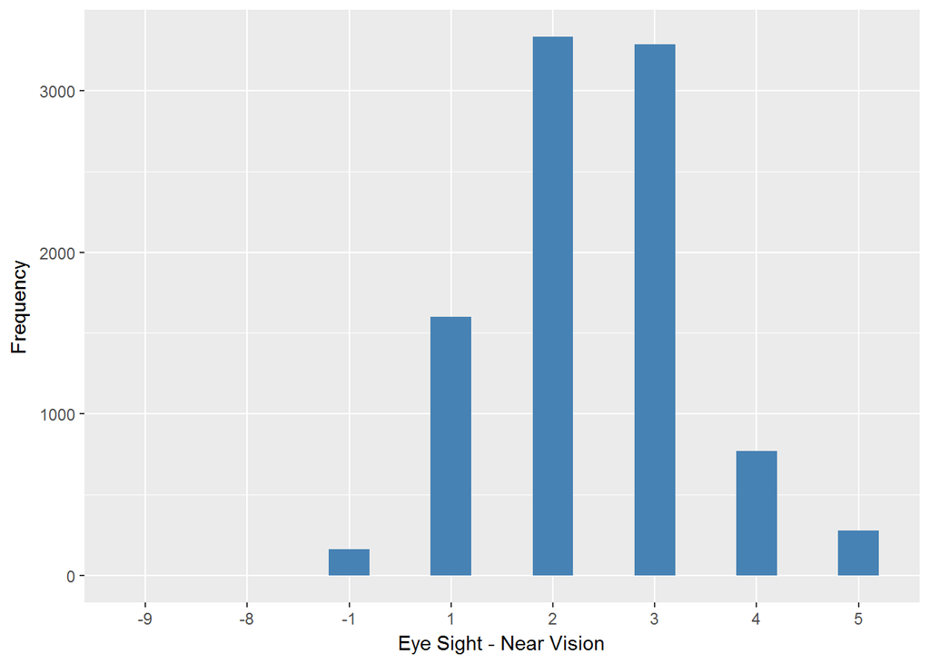

Heeye

| Sample size | Missing values |
| --- | --- |
| 9432 | 6 |

Category

|  | 1 | 2 | 3 | 4 | 5 | 6 |
| --- | --- | --- | --- | --- | --- | --- |
| Frequency | 1375.00 | 3072.00 | 3642.00 | 1002.00 | 301.00 | 34.00 |
| Percentage | 14.58 | 32.57 | 38.61 | 10.62 | 3.19 | 0.36 |

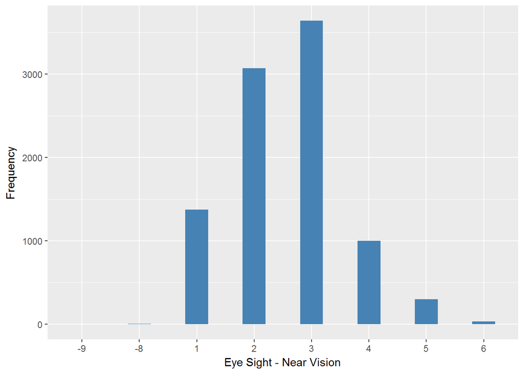

#### 2.1.2.2 Harmonisation algorithm

To compute the harmonize variable from the study-specific variable it has to be recoded as follows:

- `hepap == 1, 2, 3 into 1`
- `hepap == 4, 5 into 0`
- `hepap == -9 Refusal into 997`
- `hepap == -8 Don't know into 998`
- `hepap == -1 Item not applicable into 996`
- `heeye == 6 into 0`

**R script:**

```r
ELSA_ds_w2 <- tibble(id = ELSA_w2_eye_near$id)
ELSA_ds_w2$eye_near <- car::recode(ELSA_w2_eye_near$Hepap, "1 = '1';2 = '1';3 = '1';4 = '0'; 5 = '0';-9 = '997';-8 = '998';-1 = '996' ")

ELSA_ds_w2$eye_near[!is.na(ELSA_w2_eye_near$Heeye) & ELSA_w2_eye_near$Heeye ==
    6] <- 0

ELSA_ds_w2$eye_near <- labelled(ELSA_ds_w2$eye_near, labels = c(Yes = 0, No = 1,
    Missing = 999, Do_not_know = 998, Refuse = 997, Not_applicable = 996, Does_not_answer = 995,
    Not_attempt_not_done = 994, Disable_to_measure = 993, Impute = 992, CAPI_interviewer_error = 991))
```

#### 2.1.2.3 Statistical description of the new harmonised variable

eye_near

| Sample size | Missing values |
| --- | --- |
| 9432 | 133 |

Category

|  | 0 | 1 |
| --- | --- | --- |
| Frequency | 1081.00 | 8218.00 |
| Percentage | 11.46 | 87.13 |

Type of missing

|  | 991 | 992 | 993 | 994 | 995 | 996 | 997 | 998 | 999 | NA |
| --- | --- | --- | --- | --- | --- | --- | --- | --- | --- | --- |
| Frequency | 0 | 0 | 0 | 0 | 0 | 130.00 | 1.00 | 2.00 | 0 | 0 |
| Percentage | 0 | 0 | 0 | 0 | 0 | 1.38 | 0.01 | 0.02 | 0 | 0 |

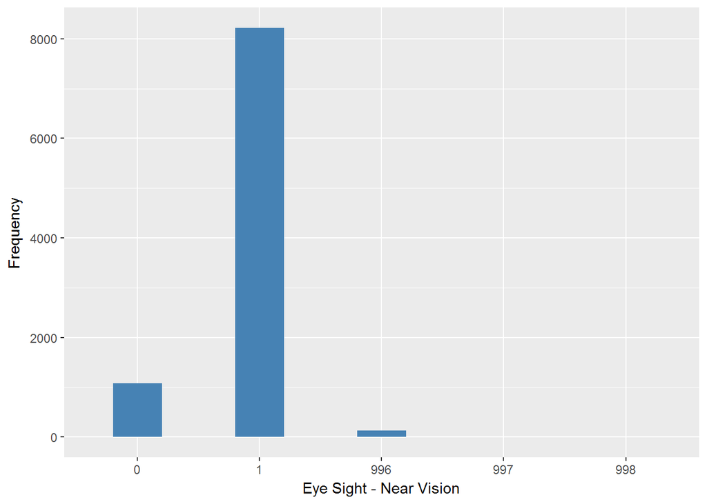

#### 2.1.2.4 Validation

|  | 4,5,heeye==6->0 | 1,2,3->1 | -1->996 | -9->997 | -8->998 |
| --- | --- | --- | --- | --- | --- |
| BeforeH | 1081 | 8218 | 130 | 1 | 2 |
| AfterH | 1081 | 8218 | 130 | 1 | 2 |

### 2.1.3 Wave 3

#### 2.1.3.1 Study-specific variable description

| **Name** | `hepap` | `heeye` |
| --- | --- | --- |
| **Label** | `How good is your eyesight for seeing things up close, like reading ordinary newspaper print (using glasses or corrective lens as usual)?` | `Self-reported eyesight (while using lenses, if appropriate)?` |
| **Table name** | `wave_3_elsa_data_v4` | `wave_3_elsa_data_v4` |
| **Categories** | `1 = ...excellent; 2 = very good; 3 = good; 4 = fair; 5 = or, poor?` | `1 = ...excellent; 2 = very good; 3 = good; 4 = fair; 5 = or, poor?; 6 = SPONTANEOUS: Registered or legally blind` |
| **Missings** | `-9 = Refusal; -8 = Don't Know; -1 = Not applicable` | `-9 = Refusal; -8 = Don't Know` |
| **Description** |  |  |

hepap

| Sample size | Missing values |
| --- | --- |
| 9771 | 259 |

Category

|  | 1 | 2 | 3 | 4 | 5 |
| --- | --- | --- | --- | --- | --- |
| Frequency | 1565.00 | 3292.00 | 3550.00 | 817.00 | 288.00 |
| Percentage | 16.02 | 33.69 | 36.33 | 8.36 | 2.95 |

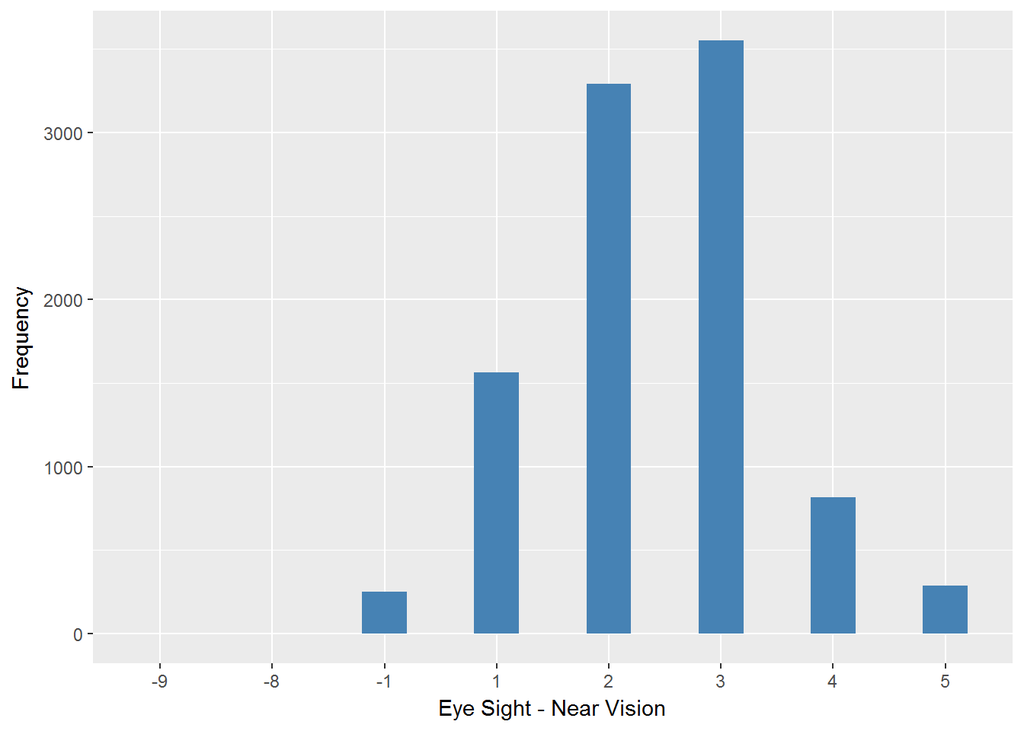

heeye

| Sample size | Missing values |
| --- | --- |
| 9771 | 7 |

Category

|  | 1 | 2 | 3 | 4 | 5 | 6 |
| --- | --- | --- | --- | --- | --- | --- |
| Frequency | 1356.00 | 3024.00 | 3921.00 | 1113.00 | 326.00 | 24.00 |
| Percentage | 13.88 | 30.95 | 40.13 | 11.39 | 3.34 | 0.25 |

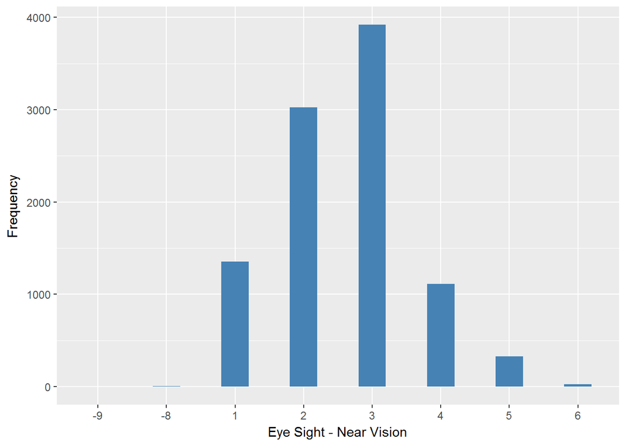

#### 2.1.3.2 Harmonisation algorithm

To compute the harmonize variable from the study-specific variable it has to be recoded as follows:

- `hepap == 1, 2, 3 into 1`
- `hepap == 4, 5 into 0`
- `hepap == -9 Refusal into 997`
- `hepap == -8 Don't know into 998`
- `hepap == -1 Item not applicable into 996`
- `heeye == 6 into 0`

**R script:**

```r
ELSA_ds_w3 <- tibble(id = ELSA_w3_eye_near$id)
ELSA_ds_w3$eye_near <- car::recode(ELSA_w3_eye_near$hepap, "1 = '1';2 = '1';3 = '1';4 = '0'; 5 = '0';-9 = '997';-8 = '998';-1 = '996' ")

ELSA_ds_w3$eye_near[!is.na(ELSA_w3_eye_near$heeye) & ELSA_w3_eye_near$heeye ==
    6] <- 0

ELSA_ds_w3$eye_near <- labelled(ELSA_ds_w3$eye_near, labels = c(Yes = 0, No = 1,
    Missing = 999, Do_not_know = 998, Refuse = 997, Not_applicable = 996, Does_not_answer = 995,
    Not_attempt_not_done = 994, Disable_to_measure = 993, Impute = 992, CAPI_interviewer_error = 991))
```

#### 2.1.3.3 Statistical description of the new harmonised variable

eye_near

| Sample size | Missing values |
| --- | --- |
| 9771 | 235 |

Category

|  | 0 | 1 |
| --- | --- | --- |
| Frequency | 1129.00 | 8407.00 |
| Percentage | 11.55 | 86.04 |

Type of missing

|  | 991 | 992 | 993 | 994 | 995 | 996 | 997 | 998 | 999 | NA |
| --- | --- | --- | --- | --- | --- | --- | --- | --- | --- | --- |
| Frequency | 0 | 0 | 0 | 0 | 0 | 229.00 | 3.00 | 3.00 | 0 | 0 |
| Percentage | 0 | 0 | 0 | 0 | 0 | 2.34 | 0.03 | 0.03 | 0 | 0 |

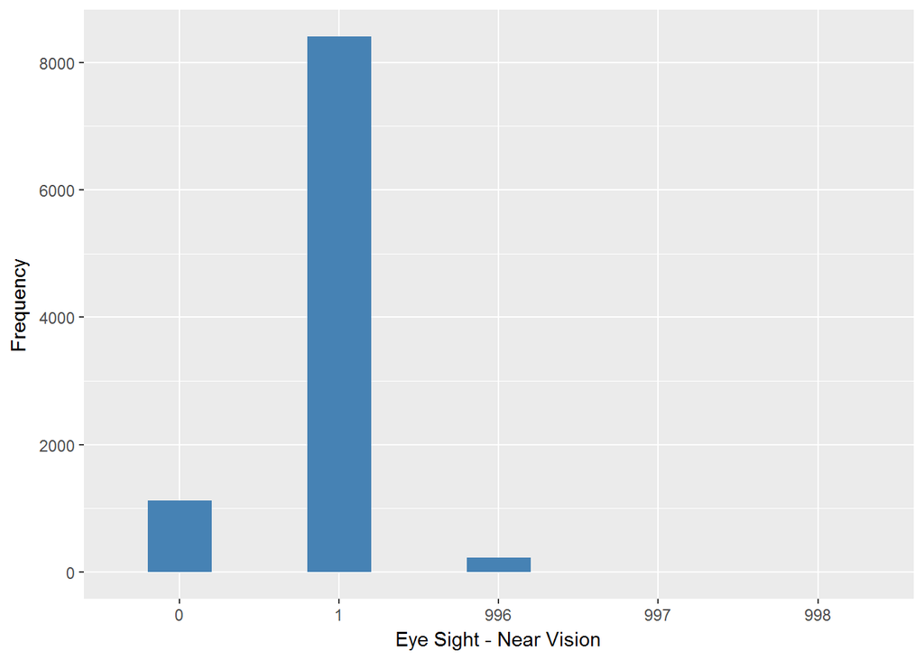

#### 2.1.3.4 Validation

|  | 4,5,heeye==6->0 | 1,2,3->1 | -1->996 | -9->997 | -8->998 |
| --- | --- | --- | --- | --- | --- |
| BeforeH | 1129 | 8407 | 229 | 3 | 3 |
| AfterH | 1129 | 8407 | 229 | 3 | 3 |

### 2.1.4 Wave 4

#### 2.1.4.1 Study-specific variable description

| **Name** | `hepap` | `heeye` |
| --- | --- | --- |
| **Label** | `How good is your eyesight for seeing things up close, like reading ordinary newspaper print (using glasses or corrective lens as usual)?` | `Self-reported eyesight (while using lenses, if appropriate)?` |
| **Table name** | `wave_4_elsa_data_v3` | `wave_4_elsa_data_v3` |
| **Categories** | `1 = ...excellent; 2 = very good; 3 = good; 4 = fair; 5 = or, poor?` | `1 = ...excellent; 2 = very good; 3 = good; 4 = fair; 5 = or, poor?; 6 = SPONTANEOUS: Registered or legally blind` |
| **Missings** | `-9 = Refusal; -8 = Don't Know; -1 = Not applicable` | `-9 = Refusal; -8 = Don't Know` |
| **Description** |  |  |

hepap

| Sample size | Missing values |
| --- | --- |
| 11050 | 500 |

Category

|  | 1 | 2 | 3 | 4 | 5 |
| --- | --- | --- | --- | --- | --- |
| Frequency | 2042.00 | 3874.00 | 3569.0 | 801.00 | 264.00 |
| Percentage | 18.48 | 35.06 | 32.3 | 7.25 | 2.39 |

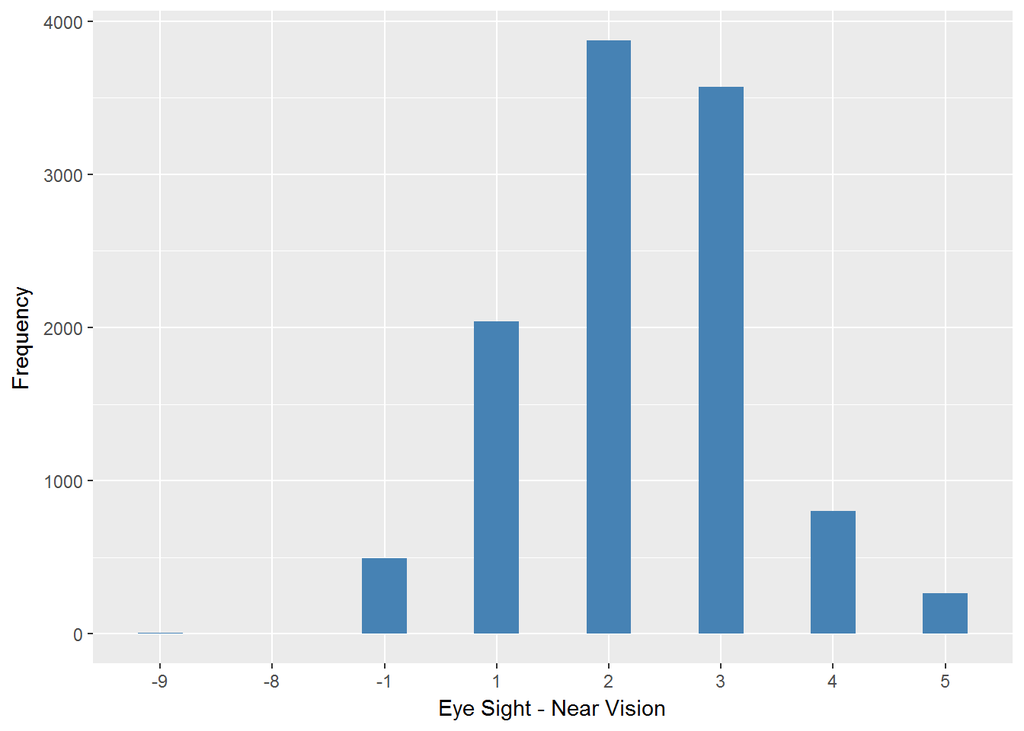

heeye

| Sample size | Missing values |
| --- | --- |
| 11050 | 8 |

Category

|  | 1 | 2 | 3 | 4 | 5 | 6 |
| --- | --- | --- | --- | --- | --- | --- |
| Frequency | 1718.00 | 3693.00 | 4166.0 | 1094.0 | 319.00 | 52.00 |
| Percentage | 15.55 | 33.42 | 37.7 | 9.9 | 2.89 | 0.47 |

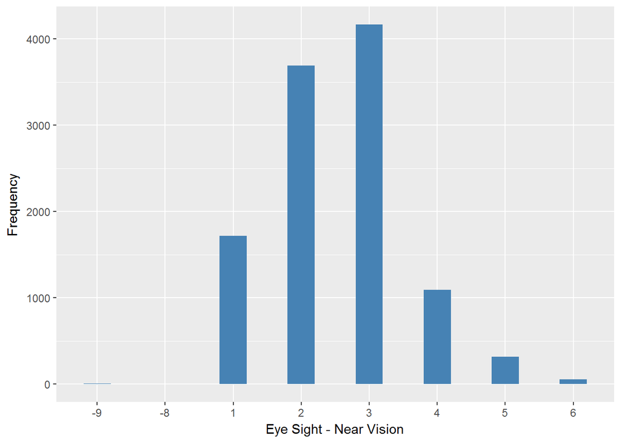

#### 2.1.4.2 Harmonisation algorithm

To compute the harmonize variable from the study-specific variable it has to be recoded as follows:

- `hepap == 1, 2, 3 into 1`
- `hepap == 4, 5 into 0`
- `hepap == -9 Refusal into 997`
- `hepap == -8 Don't know into 998`
- `hepap == -1 Item not applicable into 996`
- `heeye == 6 into 0`

**R script:**

```r
ELSA_ds_w4 <- tibble(id = ELSA_w4_eye_near$id)
ELSA_ds_w4$eye_near <- car::recode(ELSA_w4_eye_near$hepap, "1 = '1';2 = '1';3 = '1';4 = '0'; 5 = '0';-9 = '997';-8 = '998';-1 = '996' ")

ELSA_ds_w4$eye_near[!is.na(ELSA_w4_eye_near$heeye) & ELSA_w4_eye_near$heeye ==
    6] <- 0


ELSA_ds_w4$eye_near <- labelled(ELSA_ds_w4$eye_near, labels = c(Yes = 0, No = 1,
    Missing = 999, Do_not_know = 998, Refuse = 997, Not_applicable = 996, Does_not_answer = 995,
    Not_attempt_not_done = 994, Disable_to_measure = 993, Impute = 992, CAPI_interviewer_error = 991))
```

#### 2.1.4.3 Statistical description of the new harmonised variable

eye_near

| Sample size | Missing values |
| --- | --- |
| 11050 | 448 |

Category

|  | 0 | 1 |
| --- | --- | --- |
| Frequency | 1117.00 | 9485.00 |
| Percentage | 10.11 | 85.84 |

Type of missing

|  | 991 | 992 | 993 | 994 | 995 | 996 | 997 | 998 | 999 | NA |
| --- | --- | --- | --- | --- | --- | --- | --- | --- | --- | --- |
| Frequency | 0 | 0 | 0 | 0 | 0 | 440.00 | 5.00 | 3.00 | 0 | 0 |
| Percentage | 0 | 0 | 0 | 0 | 0 | 3.98 | 0.05 | 0.03 | 0 | 0 |

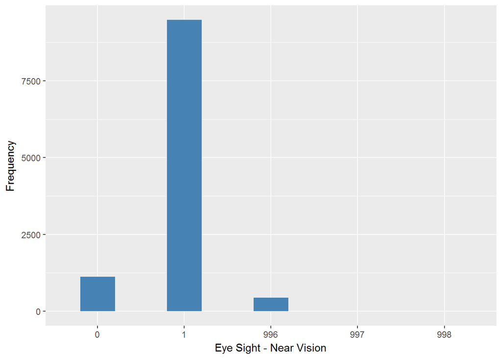

#### 2.1.4.4 Validation

|  | 4,5,heeye==6->0 | 1,2,3->1 | -1->996 | -9->997 | -8->998 |
| --- | --- | --- | --- | --- | --- |
| BeforeH | 1117 | 9485 | 440 | 5 | 3 |
| AfterH | 1117 | 9485 | 440 | 5 | 3 |

### 2.1.5 Wave 5

#### 2.1.5.1 Study-specific variable description

| **Name** | `hepap` | `heeye` |
| --- | --- | --- |
| **Label** | `How good is your eyesight for seeing things up close, like reading ordinary newspaper print (using glasses or corrective lens as usual)?` | `Self-reported eyesight (while using lenses, if appropriate)?` |
| **Table name** | `wave_5_elsa_data_v4` | `wave_5_elsa_data_v4` |
| **Categories** | `1 = ...excellent; 2 = very good; 3 = good; 4 = fair; 5 = or, poor?` | `1 = ...excellent; 2 = very good; 3 = good; 4 = fair; 5 = or, poor?; 6 = SPONTANEOUS: Registered or legally blind` |
| **Missings** | `-9 = Refusal; -8 = Don't Know; -1 = Not applicable` | `-9 = Refusal; -8 = Don't Know` |
| **Description** |  |  |

hepap

| Sample size | Missing values |
| --- | --- |
| 10274 | 591 |

Category

|  | 1 | 2 | 3 | 4 | 5 |
| --- | --- | --- | --- | --- | --- |
| Frequency | 1751.00 | 3664.00 | 3347.00 | 702.00 | 219.00 |
| Percentage | 17.04 | 35.66 | 32.58 | 6.83 | 2.13 |

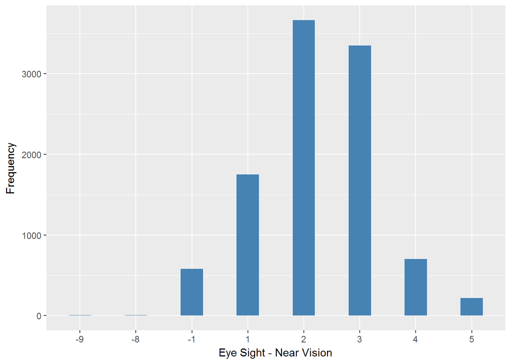

heeye

| Sample size | Missing values |
| --- | --- |
| 10274 | 12 |

Category

|  | 1 | 2 | 3 | 4 | 5 | 6 |
| --- | --- | --- | --- | --- | --- | --- |
| Frequency | 1529.00 | 3531.00 | 3821.00 | 1027 | 300.00 | 54.00 |
| Percentage | 14.88 | 34.37 | 37.19 | 10 | 2.92 | 0.53 |

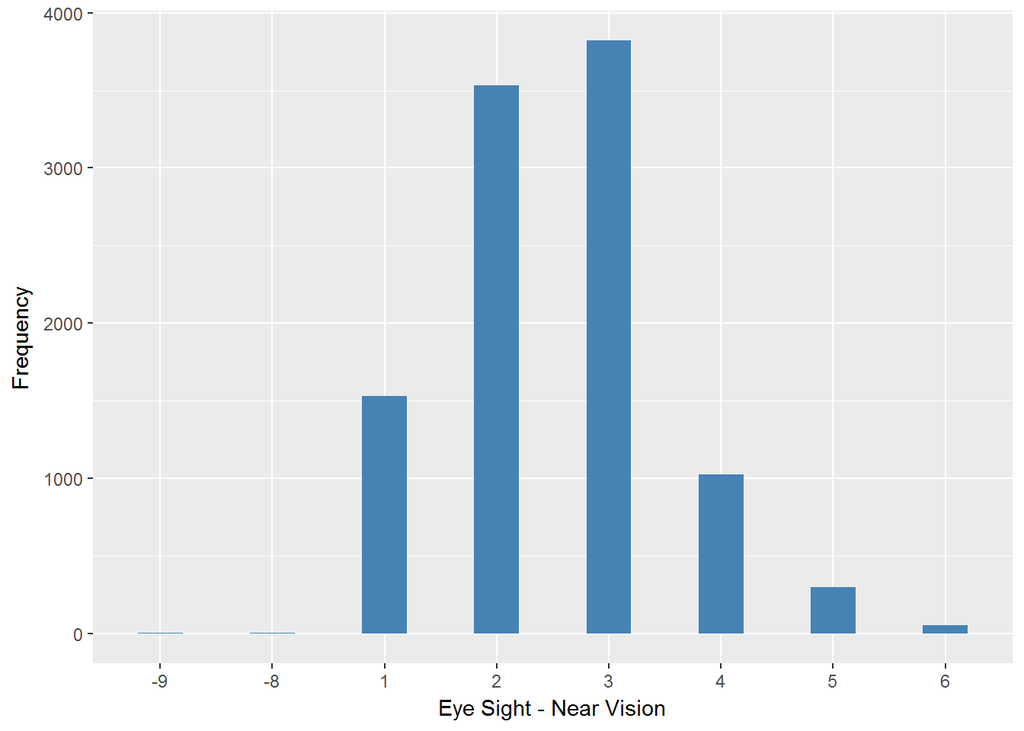

#### 2.1.5.2 Harmonisation algorithm

To compute the harmonize variable from the study-specific variable it has to be recoded as follows:

- `hepap == 1, 2, 3 into 1`
- `hepap == 4, 5 into 0`
- `hepap == -9 Refusal into 997`
- `hepap == -8 Don't know into 998`
- `hepap == -1 Item not applicable into 996`
- `heeye == 6 into 0`

**R script:**

```r
ELSA_ds_w5 <- tibble(id = ELSA_w5_eye_near$id)
ELSA_ds_w5$eye_near <- car::recode(ELSA_w5_eye_near$hepap, "1 = '1';2 = '1';3 = '1';4 = '0'; 5 = '0';-9 = '997';-8 = '998';-1 = '996' ")

ELSA_ds_w5$eye_near[!is.na(ELSA_w5_eye_near$heeye) & ELSA_w5_eye_near$heeye ==
    6] <- 0

ELSA_ds_w5$eye_near <- labelled(ELSA_ds_w5$eye_near, labels = c(Yes = 0, No = 1,
    Missing = 999, Do_not_know = 998, Refuse = 997, Not_applicable = 996, Does_not_answer = 995,
    Not_attempt_not_done = 994, Disable_to_measure = 993, Impute = 992, CAPI_interviewer_error = 991))
```

#### 2.1.5.3 Statistical description of the new harmonised variable

eye_near

| Sample size | Missing values |
| --- | --- |
| 10274 | 537 |

Category

|  | 0 | 1 |
| --- | --- | --- |
| Frequency | 975.00 | 8762.00 |
| Percentage | 9.49 | 85.28 |

Type of missing

|  | 991 | 992 | 993 | 994 | 995 | 996 | 997 | 998 | 999 | NA |
| --- | --- | --- | --- | --- | --- | --- | --- | --- | --- | --- |
| Frequency | 0 | 0 | 0 | 0 | 0 | 526.00 | 4.00 | 7.00 | 0 | 0 |
| Percentage | 0 | 0 | 0 | 0 | 0 | 5.12 | 0.04 | 0.07 | 0 | 0 |

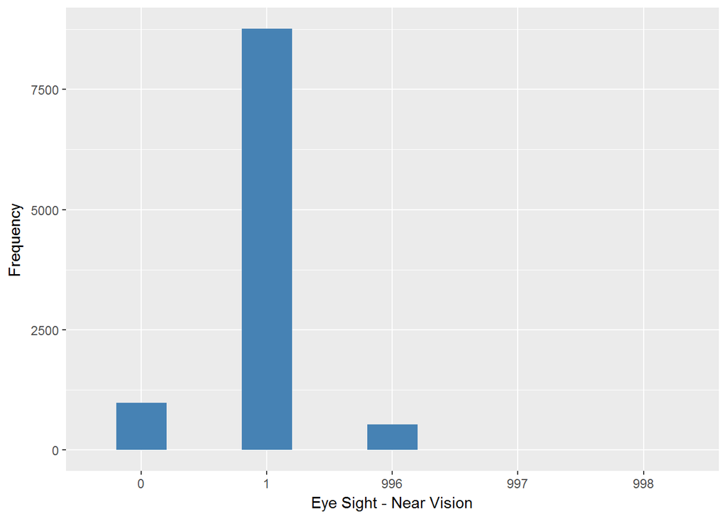

#### 2.1.5.4 Validation

|  | 4,5,heeye==6->0 | 1,2,3->1 | -1->996 | -9->997 | -8->998 |
| --- | --- | --- | --- | --- | --- |
| BeforeH | 975 | 8762 | 526 | 4 | 7 |
| AfterH | 975 | 8762 | 526 | 4 | 7 |

### 2.1.6 Wave 6

#### 2.1.6.1 Study-specific variable description

| **Name** | `hepap` | `HeEye` |
| --- | --- | --- |
| **Label** | `How good is your eyesight for seeing things up close, like reading ordinary newspaper print (using glasses or corrective lens as usual)?` | `Self-reported eyesight (while using lenses, if appropriate)?` |
| **Table name** | `wave_6_elsa_data_v2` | `wave_6_elsa_data_v2` |
| **Categories** | `1 = ...excellent; 2 = very good; 3 = good; 4 = fair; 5 = or, poor?` | `1 = ...excellent; 2 = very good; 3 = good; 4 = fair; 5 = or, poor?; 6 = SPONTANEOUS: Registered or legally blind` |
| **Missings** | `-9 = Refusal; -8 = Don't Know; -1 = Not applicable` | `-9 = Refusal; -8 = Don't Know` |
| **Description** |  |  |

Hepap

| Sample size | Missing values |
| --- | --- |
| 10601 | 663 |

Category

|  | 1 | 2 | 3 | 4 | 5 |
| --- | --- | --- | --- | --- | --- |
| Frequency | 1719.00 | 3642.00 | 3573.0 | 761.00 | 243.00 |
| Percentage | 16.22 | 34.36 | 33.7 | 7.18 | 2.29 |

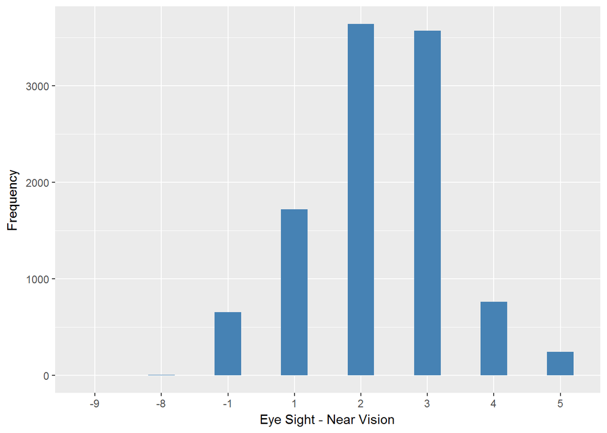

HeEye

| Sample size | Missing values |
| --- | --- |
| 10601 | 9 |

Category

|  | 1 | 2 | 3 | 4 | 5 | 6 |
| --- | --- | --- | --- | --- | --- | --- |
| Frequency | 1555.00 | 3542.00 | 4083.00 | 1038.00 | 320.00 | 54.00 |
| Percentage | 14.67 | 33.41 | 38.52 | 9.79 | 3.02 | 0.51 |

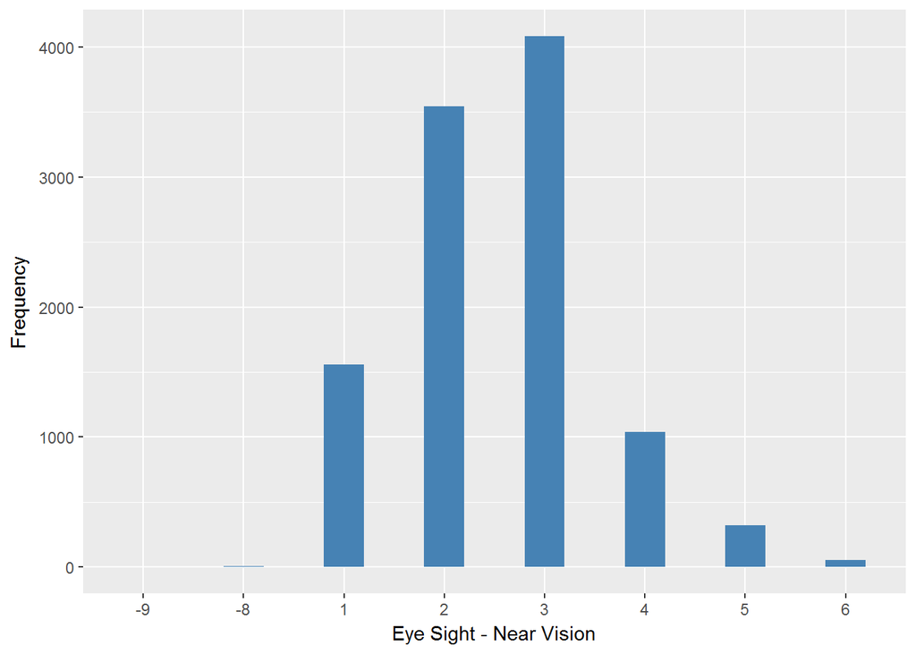

#### 2.1.6.2 Harmonisation algorithm

To compute the harmonize variable from the study-specific variable it has to be recoded as follows:

- `hepap == 1, 2, 3 into 1`
- `hepap == 4, 5 into 0`
- `hepap == -9 Refusal into 997`
- `hepap == -8 Don't know into 998`
- `hepap == -1 Item not applicable into 996`
- `heeye == 6 into 0`

**R script:**

```r
ELSA_ds_w6 <- tibble(id = ELSA_w6_eye_near$id)
ELSA_ds_w6$eye_near <- car::recode(ELSA_w6_eye_near$Hepap, "1 = '1';2 = '1';3 = '1';4 = '0'; 5 = '0';-9 = '997';-8 = '998';-1 = '996' ")

ELSA_ds_w6$eye_near[!is.na(ELSA_w6_eye_near$HeEye) & ELSA_w6_eye_near$HeEye ==
    6] <- 0


ELSA_ds_w6$eye_near <- labelled(ELSA_ds_w6$eye_near, labels = c(Yes = 0, No = 1,
    Missing = 999, Do_not_know = 998, Refuse = 997, Not_applicable = 996, Does_not_answer = 995,
    Not_attempt_not_done = 994, Disable_to_measure = 993, Impute = 992, CAPI_interviewer_error = 991))
```

#### 2.1.6.3 Statistical description of the new harmonised variable

eye_near

| Sample size | Missing values |
| --- | --- |
| 10601 | 609 |

Category

|  | 0 | 1 |
| --- | --- | --- |
| Frequency | 1058.00 | 8934.00 |
| Percentage | 9.98 | 84.28 |

Type of missing

|  | 991 | 992 | 993 | 994 | 995 | 996 | 997 | 998 | 999 | NA |
| --- | --- | --- | --- | --- | --- | --- | --- | --- | --- | --- |
| Frequency | 0 | 0 | 0 | 0 | 0 | 602.00 | 3.00 | 4.00 | 0 | 0 |
| Percentage | 0 | 0 | 0 | 0 | 0 | 5.68 | 0.03 | 0.04 | 0 | 0 |

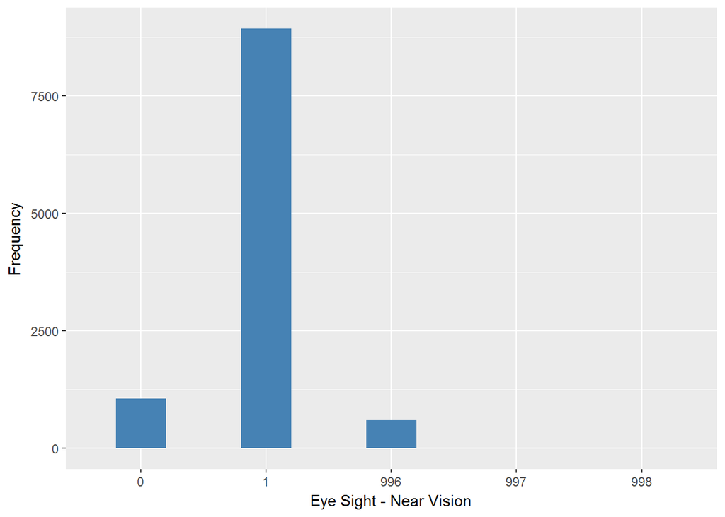

#### 2.1.6.4 Validation

|  | 4,5,heeye==6->0 | 1,2,3->1 | -1->996 | -9->997 | -8->998 |
| --- | --- | --- | --- | --- | --- |
| BeforeH | 1058 | 8934 | 602 | 3 | 4 |
| AfterH | 1058 | 8934 | 602 | 3 | 4 |

### 2.1.7 Wave 7

#### 2.1.7.1 Study-specific variable description

| **Name** | `hepap` | `HeEye` |
| --- | --- | --- |
| **Label** | `How good is your eyesight for seeing things up close, like reading ordinary newspaper print (using glasses or corrective lens as usual)?` | `Self-reported eyesight (while using lenses, if appropriate)?` |
| **Table name** | `wave_7_elsa_data` | `wave_7_elsa_data` |
| **Categories** | `1 = ...excellent; 2 = very good; 3 = good; 4 = fair; 5 = or, poor?` | `1 = ...excellent; 2 = very good; 3 = good; 4 = fair; 5 = or, poor?; 6 = SPONTANEOUS: Registered or legally blind` |
| **Missings** | `-8 = Don't Know; -1 = Not applicable` | `-8 = Don't Know` |
| **Description** |  |  |

Hepap

| Sample size | Missing values |
| --- | --- |
| 9666 | 641 |

Category

|  | 1 | 2 | 3 | 4 | 5 |
| --- | --- | --- | --- | --- | --- |
| Frequency | 1710.00 | 3398.00 | 3128.00 | 591.00 | 198.00 |
| Percentage | 17.69 | 35.15 | 32.36 | 6.11 | 2.05 |

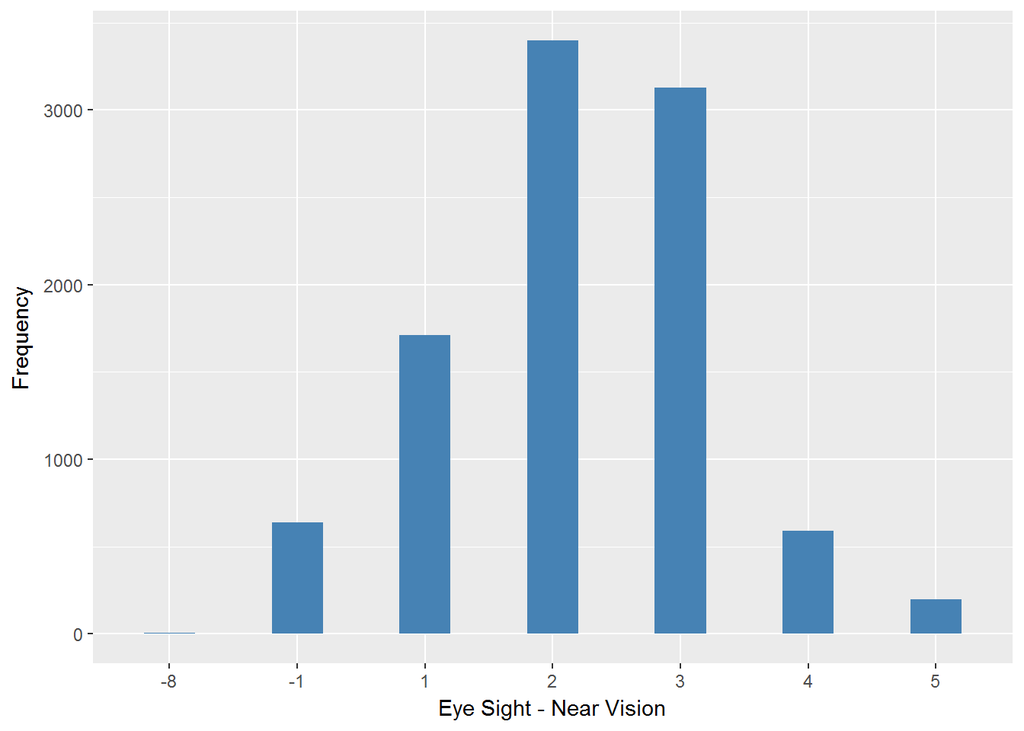

HeEye

| Sample size | Missing values |
| --- | --- |
| 9666 | 9 |

Category

|  | 1 | 2 | 3 | 4 | 5 | 6 |
| --- | --- | --- | --- | --- | --- | --- |
| Frequency | 1467.00 | 3285.00 | 3632.00 | 969.00 | 256.00 | 48.0 |
| Percentage | 15.18 | 33.99 | 37.58 | 10.02 | 2.65 | 0.5 |

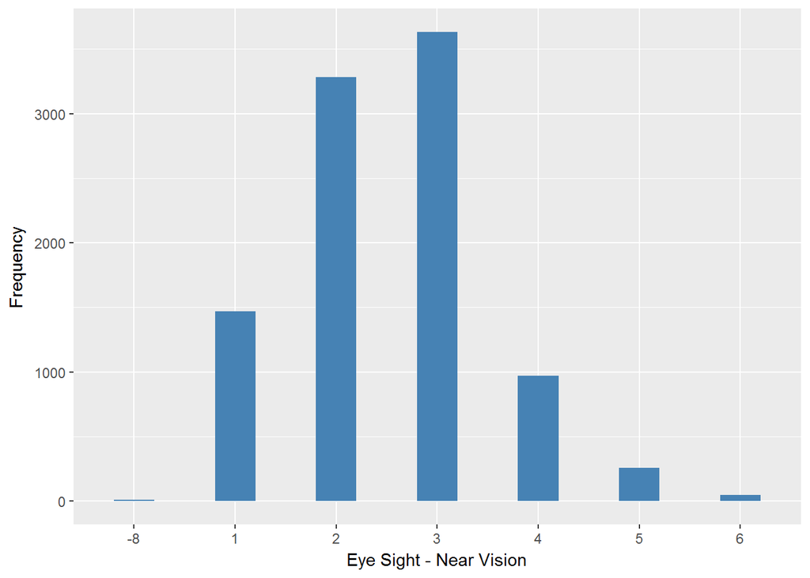

#### 2.1.7.2 Harmonisation algorithm

To compute the harmonize variable from the study-specific variable it has to be recoded as follows:

- `hepap == 1, 2, 3 into 1`
- `hepap == 4, 5 into 0`
- `hepap == -8 Don't know into 998`
- `hepap == -1 Item not applicable into 996`
- `heeye == 6 into 0`

**R script:**

```r
ELSA_ds_w7 <- tibble(id = ELSA_w7_eye_near$id)
ELSA_ds_w7$eye_near <- car::recode(ELSA_w7_eye_near$Hepap, "1 = '1';2 = '1';3 = '1';4 = '0'; 5 = '0';-8 = '998';-1 = '996' ")

ELSA_ds_w7$eye_near[!is.na(ELSA_w7_eye_near$HeEye) & ELSA_w7_eye_near$HeEye ==
    6] <- 0

ELSA_ds_w7$eye_near <- labelled(ELSA_ds_w7$eye_near, labels = c(Yes = 0, No = 1,
    Missing = 999, Do_not_know = 998, Refuse = 997, Not_applicable = 996, Does_not_answer = 995,
    Not_attempt_not_done = 994, Disable_to_measure = 993, Impute = 992, CAPI_interviewer_error = 991))
```

#### 2.1.7.3 Statistical description of the new harmonised variable

eye_near

| Sample size | Missing values |
| --- | --- |
| 9666 | 593 |

Category

|  | 0 | 1 |
| --- | --- | --- |
| Frequency | 837.00 | 8236.00 |
| Percentage | 8.66 | 85.21 |

Type of missing

|  | 991 | 992 | 993 | 994 | 995 | 996 | 997 | 998 | 999 | NA |
| --- | --- | --- | --- | --- | --- | --- | --- | --- | --- | --- |
| Frequency | 0 | 0 | 0 | 0 | 0 | 590.0 | 0 | 3.00 | 0 | 0 |
| Percentage | 0 | 0 | 0 | 0 | 0 | 6.1 | 0 | 0.03 | 0 | 0 |

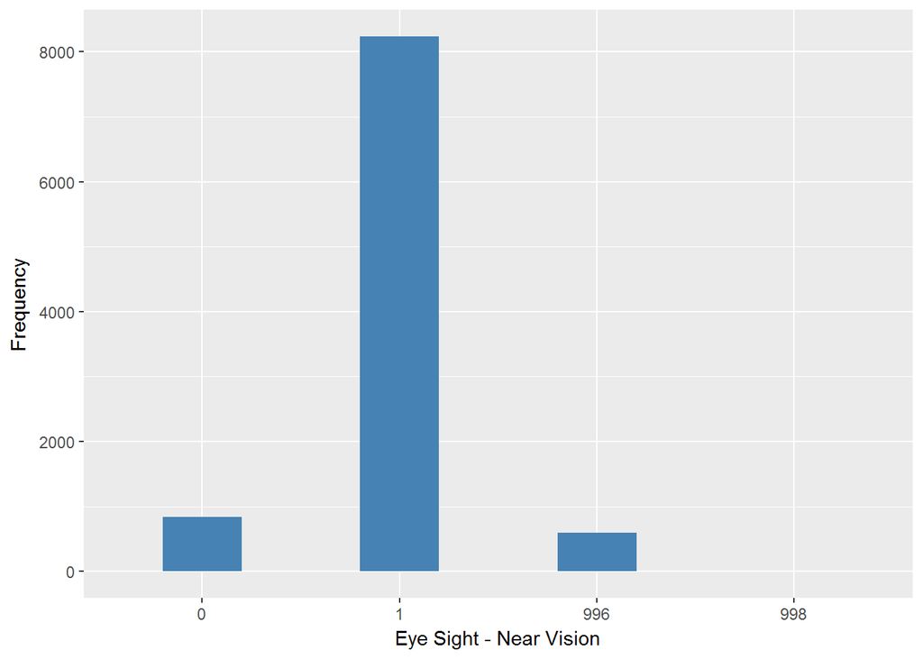

#### 2.1.7.4 Validation

|  | 4,5,heeye==6->0 | 1,2,3->1 | -1->996 | -8->998 |
| --- | --- | --- | --- | --- |
| BeforeH | 837 | 8236 | 590 | 3 |
| AfterH | 837 | 8236 | 590 | 3 |

## 2.2 Summary of descriptive statistics of the harmonised variable accross populations and waves

Two tables are generated:

1. Percentages of categories in each harmonised variable.
2. Frequencies and percentages of individuals with different trajectories. To avoid too large table, Only trajectories with percentages larger than 0.3 are shown.

**R script:**

```r
ELSA_ds_w1$eye_near <- labelled(ELSA_ds_w1$eye_near, labels = c(Presence = 0,
    Absence = 1, Missing = 999, Do_not_know = 998, Refuse = 997, Not_applicable = 996,
    Does_not_answer = 995, Not_attempt_not_done = 994, Disable_to_measure = 993,
    Impute = 992, CAPI_interviewer_error = 991))
ELSA_ds_w2$eye_near <- labelled(ELSA_ds_w2$eye_near, labels = c(Presence = 0,
    Absence = 1, Missing = 999, Do_not_know = 998, Refuse = 997, Not_applicable = 996,
    Does_not_answer = 995, Not_attempt_not_done = 994, Disable_to_measure = 993,
    Impute = 992, CAPI_interviewer_error = 991))
ELSA_ds_w3$eye_near <- labelled(ELSA_ds_w3$eye_near, labels = c(Presence = 0,
    Absence = 1, Missing = 999, Do_not_know = 998, Refuse = 997, Not_applicable = 996,
    Does_not_answer = 995, Not_attempt_not_done = 994, Disable_to_measure = 993,
    Impute = 992, CAPI_interviewer_error = 991))
ELSA_ds_w4$eye_near <- labelled(ELSA_ds_w4$eye_near, labels = c(Presence = 0,
    Absence = 1, Missing = 999, Do_not_know = 998, Refuse = 997, Not_applicable = 996,
    Does_not_answer = 995, Not_attempt_not_done = 994, Disable_to_measure = 993,
    Impute = 992, CAPI_interviewer_error = 991))
ELSA_ds_w5$eye_near <- labelled(ELSA_ds_w5$eye_near, labels = c(Presence = 0,
    Absence = 1, Missing = 999, Do_not_know = 998, Refuse = 997, Not_applicable = 996,
    Does_not_answer = 995, Not_attempt_not_done = 994, Disable_to_measure = 993,
    Impute = 992, CAPI_interviewer_error = 991))
ELSA_ds_w6$eye_near <- labelled(ELSA_ds_w6$eye_near, labels = c(Presence = 0,
    Absence = 1, Missing = 999, Do_not_know = 998, Refuse = 997, Not_applicable = 996,
    Does_not_answer = 995, Not_attempt_not_done = 994, Disable_to_measure = 993,
    Impute = 992, CAPI_interviewer_error = 991))
ELSA_ds_w7$eye_near <- labelled(ELSA_ds_w7$eye_near, labels = c(Presence = 0,
    Absence = 1, Missing = 999, Do_not_know = 998, Refuse = 997, Not_applicable = 996,
    Does_not_answer = 995, Not_attempt_not_done = 994, Disable_to_measure = 993,
    Impute = 992, CAPI_interviewer_error = 991))

tt <- frq(ELSA_ds_w1$eye_near)[[1]][, c(1:2, 4)]
tt[4] <- frq(ELSA_ds_w2$eye_near)[[1]][, c(4)]
tt[5] <- frq(ELSA_ds_w3$eye_near)[[1]][, c(4)]
tt[6] <- frq(ELSA_ds_w4$eye_near)[[1]][, c(4)]
tt[7] <- frq(ELSA_ds_w5$eye_near)[[1]][, c(4)]
tt[8] <- frq(ELSA_ds_w6$eye_near)[[1]][, c(4)]
tt[9] <- frq(ELSA_ds_w7$eye_near)[[1]][, c(4)]
tt[13, ] <- c("n", "sample size", length(ELSA_ds_w1$eye_near), length(ELSA_ds_w2$eye_near),
    length(ELSA_ds_w3$eye_near), length(ELSA_ds_w4$eye_near), length(ELSA_ds_w5$eye_near),
    length(ELSA_ds_w6$eye_near), length(ELSA_ds_w7$eye_near))
names(tt) <- c("val", "label", "w1", "w2", "w3", "w4", "w5", "w6", "w7")
kable(tt)
```

| val | label | w1 | w2 | w3 | w4 | w5 | w6 | w7 |
| --- | --- | --- | --- | --- | --- | --- | --- | --- |
| 0 | Presence | 11.98 | 11.46 | 11.55 | 10.11 | 9.49 | 9.98 | 8.66 |
| 1 | Absence | 86.47 | 87.13 | 86.04 | 85.84 | 85.28 | 84.28 | 85.21 |
| 991 | CAPI_interviewer_error | 0 | 0 | 0 | 0 | 0 | 0 | 0 |
| 992 | Impute | 0 | 0 | 0 | 0 | 0 | 0 | 0 |
| 993 | Disable_to_measure | 0 | 0 | 0 | 0 | 0 | 0 | 0 |
| 994 | Not_attempt_not_done | 0 | 0 | 0 | 0 | 0 | 0 | 0 |
| 995 | Does_not_answer | 0 | 0 | 0 | 0 | 0 | 0 | 0 |
| 996 | Not_applicable | 1.41 | 1.38 | 2.34 | 3.98 | 5.12 | 5.68 | 6.1 |
| 997 | Refuse | 0.04 | 0.01 | 0.03 | 0.05 | 0.04 | 0.03 | 0 |
| 998 | Do_not_know | 0.1 | 0.02 | 0.03 | 0.03 | 0.07 | 0.04 | 0.03 |
| 999 | Missing | 0 | 0 | 0 | 0 | 0 | 0 | 0 |
| NA | NA | 0 | 0 | 0 | 0 | 0 | 0 | 0 |
| n | sample size | 12099 | 9432 | 9771 | 11050 | 10274 | 10601 | 9666 |

```r
dbb <- merge(ELSA_m_ds_w1, ELSA_m_ds_w2, by = "id", suffixes = c(".w1", ".w2"),
    all = T)
dbb <- merge(dbb, ELSA_m_ds_w3, by = "id", all = T)
dbb <- merge(dbb, ELSA_m_ds_w4, by = "id", suffixes = c(".w3", ".w4"), all = T)
dbb <- merge(dbb, ELSA_m_ds_w5, by = "id", all = T)
dbb <- merge(dbb, ELSA_m_ds_w6, by = "id", suffixes = c(".w5", ".w6"), all = T)
dbb <- merge(dbb, ELSA_m_ds_w7, by = "id", all = T)
names(dbb) <- c("id", "w1", "w2", "w3", "w4", "w5", "w6", "w7")
v.dbb <- paste(dbb[, 2], dbb[, 3], dbb[, 4], dbb[, 5], dbb[, 6], dbb[, 7], dbb[,
    8], sep = "")
f.dbb <- frq(v.dbb)[[1]][, c(1, 2, 4)]
kable(f.dbb[f.dbb[, 3] >= 0.3, ])
```

|  | val | frq | raw.prc |
| --- | --- | --- | --- |
| 29 | 000NANANANA | 55 | 0.30 |
| 78 | 00NANANANANA | 97 | 0.52 |
| 134 | 0111111 | 112 | 0.61 |
| 171 | 01NANANANANA | 91 | 0.49 |
| 215 | 0NANANANANANA | 369 | 2.00 |
| 272 | 1011111 | 91 | 0.49 |
| 303 | 10NANANANANA | 121 | 0.65 |
| 331 | 1101111 | 92 | 0.50 |
| 352 | 110NANANANA | 67 | 0.36 |
| 366 | 1110111 | 77 | 0.42 |
| 378 | 1111011 | 80 | 0.43 |
| 383 | 1111101 | 117 | 0.63 |
| 385 | 1111110 | 120 | 0.65 |
| 386 | 1111111 | 2839 | 15.36 |
| 387 | 111111NA | 387 | 2.09 |
| 390 | 11111NANA | 306 | 1.66 |
| 399 | 1111NANANA | 419 | 2.27 |
| 411 | 111NA111 | 75 | 0.41 |
| 424 | 111NANANANA | 697 | 3.77 |
| 443 | 11NA1111 | 77 | 0.42 |
| 468 | 11NANANANANA | 1026 | 5.55 |
| 495 | 1NA11111 | 67 | 0.36 |
| 511 | 1NA1NANANANA | 85 | 0.46 |
| 550 | 1NANANANANANA | 1761 | 9.52 |
| 653 | NANA11111 | 596 | 3.22 |
| 654 | NANA1111NA | 92 | 0.50 |
| 657 | NANA111NANA | 74 | 0.40 |
| 662 | NANA11NANANA | 109 | 0.59 |
| 679 | NANA1NANANANA | 301 | 1.63 |
| 716 | NANANA1111 | 1275 | 6.90 |
| 717 | NANANA111NA | 189 | 1.02 |
| 719 | NANANA11NANA | 159 | 0.86 |
| 727 | NANANA1NANANA | 330 | 1.78 |
| 740 | NANANANANA01 | 59 | 0.32 |
| 743 | NANANANANA11 | 758 | 4.10 |
| 744 | NANANANANA1NA | 230 | 1.24 |
| 746 | NANANANANANA1 | 432 | 2.34 |
| 747 | NANANANANANANA | 464 | 2.51 |

# 3 Quality estimation

No comments.